# 05_09_2020

## The Daily Graph.

```
05/09/2020
```

The table and graphs follow. After these there is a brief explanation of what I'd like to figure out next. The texts in the posts are written writing in markdown. If you know html, markdown is quicker and easier.  
By the way, as usual, there was a one line fix to my formatting problem. I just had to find it.

Summary Statistics for the selected counties.

[output not shown]

## Today's Graph

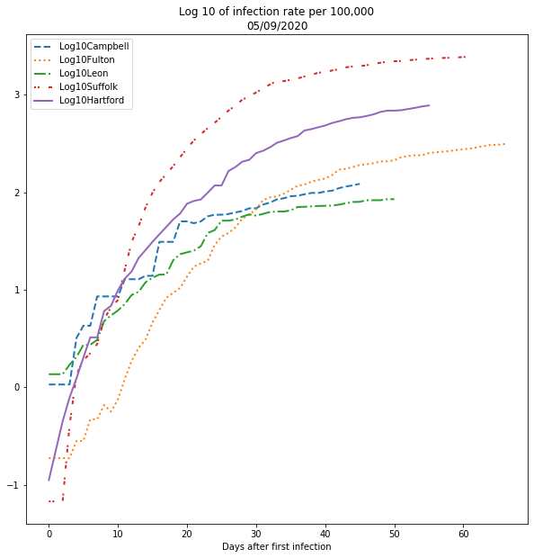

### What's next?

There is (at least visually) two patterns of increase. I'd like to start exploring this a bit.  
The ideas here orignated in a SAS blog that I subscribe to (and highly recommend).  
https://blogs.sas.com/content/iml/2020/04/01/estimate-doubling-time-exponential-growth.html?utm_source=feedburner&utm_medium=email&utm_campaign=Feed%3A+TheDoLoop+%28The+DO+Loop%29

A confession: I started with SAS, and things would have gone quicker if I'd have stayed with it. But I thought and still do that it was a good opportunity to increase my knowledge of python. So, things tend to go a bit slower.

The basic idea is that we assume exponential growth: at any time $t$ the cumulative cases ($y$) are:

$y=e^{\beta t}$  
and $log(y) = \beta t$

This formalization allows us to approach the problem using a simple linear model approach. The question becomes is $\beta$ constant. If not, where are the changes, and at what point, if at all, does $\beta$ become essentially zero (flattening the curve).

I plan to start with a single county before moving to multiple counties.  
Thoughts are appreciated.